# MATH 241: Homework 04

Dean Young

Due Friday 2015/4/17 5:00pm on Moodle

## NOTE: QUESTION 1 CONTAINS SENSITIVE DATA AND IS COMMENTED OUT OF THIS REPORT.

## Question 1:

Consider the breast cancer from HW02. Plot, using the `ww` shapefiles provided in Lecture 20, three maps:

- A map of overall breast cancer incidence rate for each census tract: $\frac{y_i}{N_i}$ where for each census tract $i=1,\ldots,n$
  - $y_i$ is the total number of cases
  - $N_i$ is the total number of people
- A map of the median income **quintiles**. i.e. your map should be a [chrolopleth map](http://2.bp.blogspot.com/_Vod56KuZXlk/S9IdL4yW14I/AAAAAAAAAFc/jHIE6fPuQvM/s1600/standardized+c+map.PNG) involving only 5 colors.
- A map of that gives a sense of census tracts with high and low breast cancer incidence rates *while taking income into account*. The approach I’m thinking of is rather simple mathematically, but requires some thought to come up with.

Notes:

- You should use the solutions from HW02.
- Do not import the shapefiles using the code from Lecture 20, but rather the `readOGR()` func`tion from Lectures 23 and 25.

## Question 2:

Download the results of the 2000 election from the [School of Public Affairs at American University in DC](http://www.american.edu/spa/ccps/Data-Sets.cfm) and create two maps involving only the lower 48 states that show:

- The proportion of people who voted for Bush at a **state** level
- The proportion of people who voted for Bush at a **county** level

where

- Counties are filled with red when they tend to favor Bush
- Counties are filled with blue when they tend to not favor Bush
- Counties are filled with purple when they tend to be split

Then answer the following questions:

1. Comment on the biggest differences when changing from “county” resolution to “state” resolution.
2. Comment on how the maps align with the idea of the [Nine Nations of North America](http://en.wikipedia.org/wiki/The_Nine_Nations_of_North_America)
3. Which states exhibit the greatest **within state heterogeneity** in voting? Come up with a mathematical justification.

Notes:

- Hint: `scale_fill_gradient2(name="", low="blue", high="red", mid="purple")` for the appropriate “mid” point. See the ggplot2 webpage for this command for inspiration.
- I believe the county map is from 2010, whereas the election data is from 2000, as such certain census tracts will not match up. The number is not that large.
- [Counties in Virginia](http://en.wikipedia.org/wiki/List_of_counties_in_Virginia)

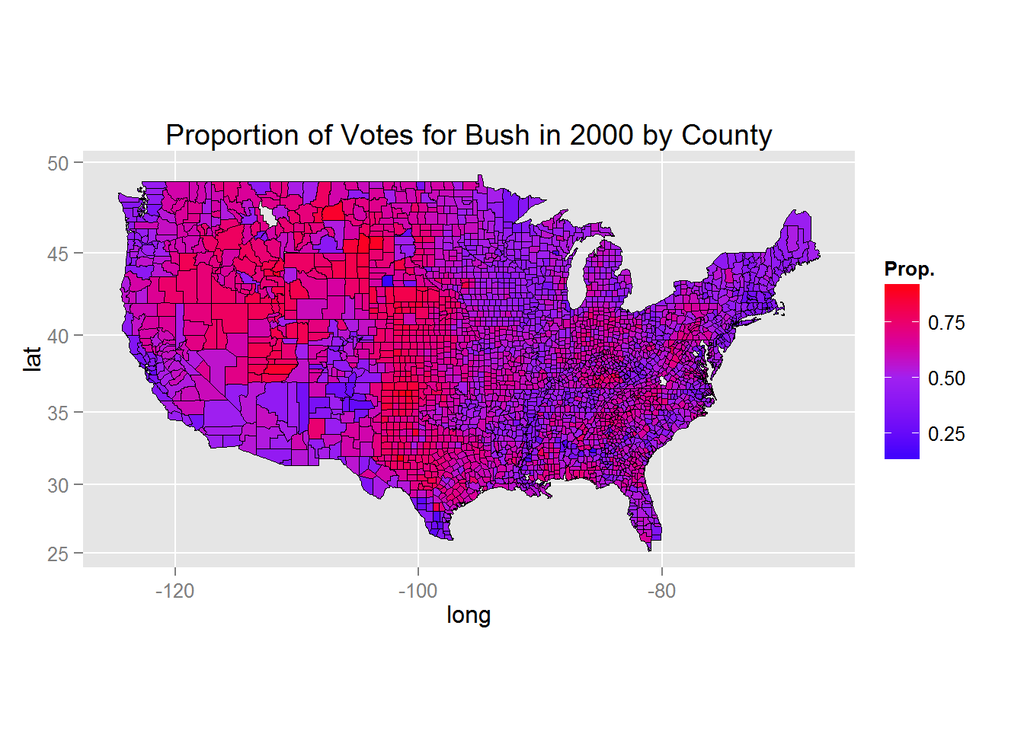

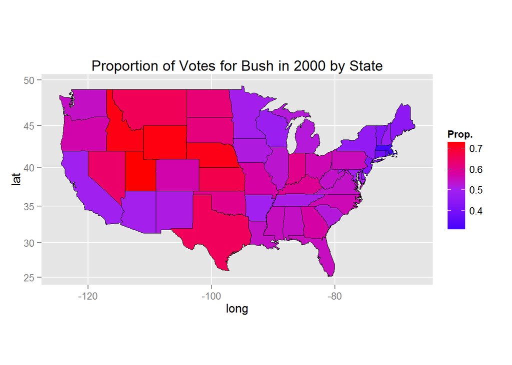

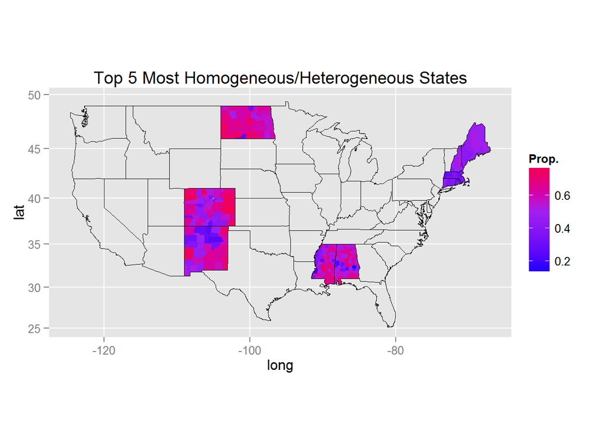

The voting patterns on the state level seem to somewhat segregate as the “Nine Nations of America” would suggest. Each “nation” appears to have a closely uniform color on the map meaning each state voted at roughly same proportions as other states in the same “nation”.